# Tidy Tuesday Eissions

### Purpose

As a person concerned with and involved in climate adaptation+ mitigation efforts, this project was begun to allow me observe raw emissions data and answer my hypothesis.

The profit motive cannot be extricated from the production and burning of fossil fuels so my hypothesis is two-fold: - Emissions from profitable fuels will be higher as they will be bought and sold more not just for use but as assets. - State-Owned Entities provide a wrinkle in the profit question because the primary goal is providing for the citizens. Thus, they are likely to be older than private companies and have higher production amounts and usage.

As we go on, I will explore the dataset, I will explain the components of these data set as well as terminologies used.

### Libraries

```r
# Install and load necessary packages

#Data Wrangling
library(dplyr)
library(vtable)
```

```r
#Graphing
library(ggplot2)
library(GGally)
#Fancy Graphing
library(arules)
library(hrbrthemes)
library(viridis)
library(treemapify)
```

# Preliminary Exploration

```r
# read  file from our current directory
edata <- read.csv("emissions_medium_granularity.csv")
```

```r
cat("There are ", ncol(edata), "columns containing", nrow(edata), "data entries.")
```

```
## There are  7 columns containing 14891 data entries.
```

```r
Columns = names(edata)
print(Columns)
```

```
## [1] "year"                   "parent_entity"          "parent_type"
## [4] "commodity"              "production_value"       "production_unit"
## [7] "total_emissions_MtCO2e"
```

In an R Markdown file, I had checked for null values and duplicates and found none. (A data set on a subject matter like this will be hard-pressed to have any duplicate entries)

```r
print("The phrase 'MtCO2e' is the unit 'Million tonneds of carbon dioxide equivalent' where the effect of a greenhouse gas has been standardized to the unit of carbon dioxide. But it is a clunky column name for analysis so I will rename it.")
```

```
## [1] "The phrase 'MtCO2e' is the unit 'Million tonneds of carbon dioxide equivalent' where the effect of a greenhouse gas has been standardized to the unit of carbon dioxide. But it is a clunky column name for analysis so I will rename it."
```

```r
#Renaming emissions column into something I can remember
data <- edata %>%
  rename(total_emissions = total_emissions_MtCO2e)
```

This data comes from an organization called ‘Carbon Majors’, whose database was created to link emissions to fossil fuel production companies,

Emissions can be pollutants - harmful to the health and lungs. Others overheat our planets causing the backlash in weather you accept or not.

```r
summary(data)
```

```
##       year      parent_entity      parent_type         commodity
##  Min.   :1854   Length:14891       Length:14891       Length:14891
##  1st Qu.:1977   Class :character   Class :character   Class :character
##  Median :2000   Mode  :character   Mode  :character   Mode  :character
##  Mean   :1992
##  3rd Qu.:2013
##  Max.   :2023
##  production_value    production_unit    total_emissions
##  Min.   :4.400e-03   Length:14891       Min.   :   0.0003
##  1st Qu.:8.162e+00   Class :character   1st Qu.:   9.0211
##  Median :4.062e+01   Mode  :character   Median :  30.5957
##  Mean   :3.575e+02                      Mean   :  93.2057
##  3rd Qu.:2.337e+02                      3rd Qu.:  91.2782
##  Max.   :2.719e+04                      Max.   :3797.9593
```

```r
paste("There are", n_distinct(data$parent_entity), "companies in this data set")
```

```
## [1] "There are 180 companies in this data set"
```

```r
Company_Types <- data %>% distinct(parent_type) %>% arrange(parent_type)
print(Company_Types)
```

```
##              parent_type
## 1 Investor-owned Company
## 2           Nation State
## 3     State-owned Entity
```

```r
#Count and print companies per type and perhaps histogram
```

From the CarbonMajors README: “The assessed entities are divided into three entity types: investor-owned companies, state-owned companies, and nation-state producers. **Investor-owned companies** include both publicly listed and privately held producers. **Nation-state producers** are used primarily in the coal sector and are included only when investor owned or state-owned companies haven’t been established or played a minor role in the relevant country. **State-owned companies** are often partially owned by institutional or individual shareholders. These are considered state owned if more than fifty percent of shares are controlled by the state.”

```r
Commodities <- data %>% distinct(commodity) %>% arrange(commodity)
print(Commodities)
```

```
##             commodity
## 1     Anthracite Coal
## 2     Bituminous Coal
## 3              Cement
## 4        Lignite Coal
## 5  Metallurgical Coal
## 6         Natural Gas
## 7           Oil & NGL
## 8 Sub-Bituminous Coal
## 9        Thermal Coal
```

```r
Unit <- data %>% distinct(production_unit) %>% arrange(production_unit)
print(Unit)
```

```
##      production_unit
## 1             Bcf/yr
## 2 Million Tonnes CO2
## 3     Million bbl/yr
## 4  Million tonnes/yr
```

```r
Year <- data %>% distinct(year) %>% arrange(year)
paste("This dataset covers", n_distinct(data$year), "years, from 1854 to 2023.")
```

```
## [1] "This dataset covers 170 years, from 1854 to 2023."
```

# Analysis

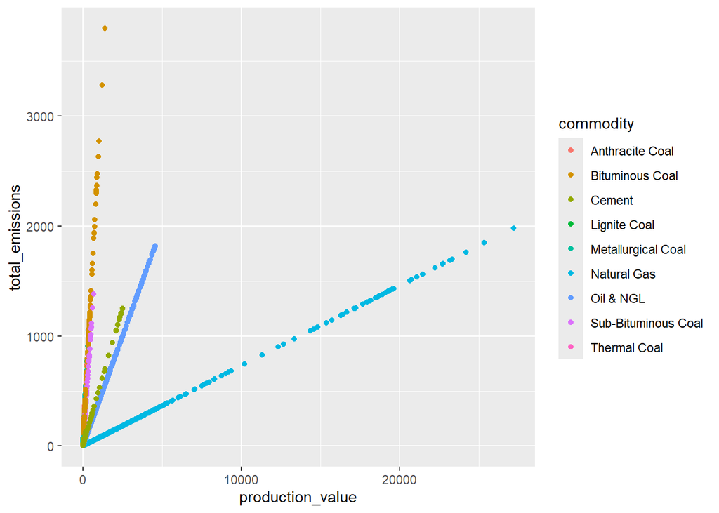

```r
ggplot(data, aes(production_value, total_emissions)) +
  geom_point(aes(colour = commodity))
```

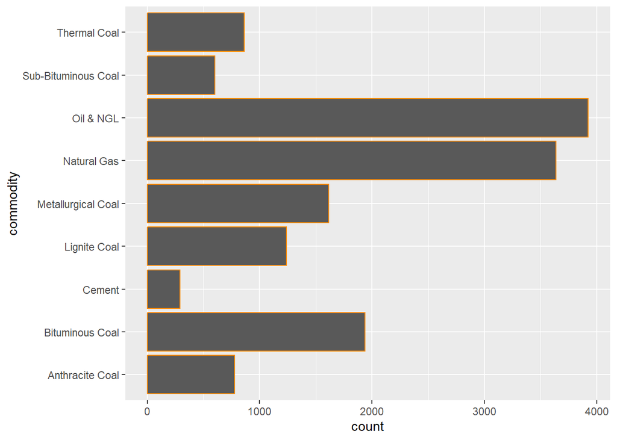

```r
 data %>%
  ggplot(aes(commodity)) +
  coord_flip() +
  geom_bar(color = "darkorange")
```

The closest I can get to observing the production amount is by counting how often the commodities appear in the dataset. But do these counts change over time.

```r
#Count of COmmodities over time
```

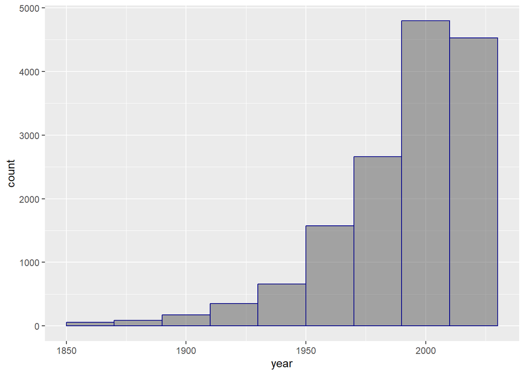

```r
ggplot(data=data, aes(x=year, fill=total_emissions)) +
  geom_histogram(binwidth = 20, alpha=0.5, position="identity", color = 'darkblue')
```

This graph can also estimate how much commodity is produced over time.

```r
#Time graphs of count coloured by
#commodity
#paret type
#over time
```

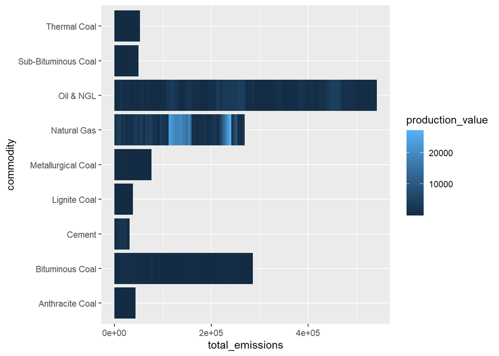

```r
ggplot(data) +
  aes(x = commodity, fill = production_value, y = total_emissions) +
  coord_flip() +
  geom_col()
```

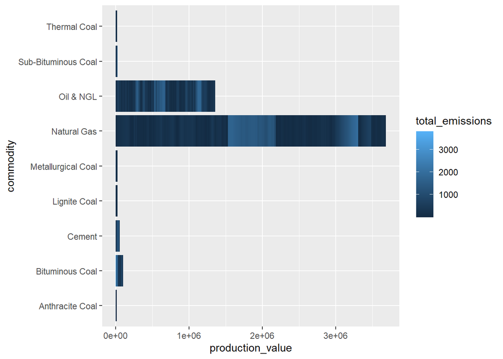

```r
ggplot(data) +
  aes(x = commodity, fill = total_emissions, y = production_value) +
  coord_flip() +
  geom_col()
```

```r
filter(data, total_emissions > 3000)
```

| year | parent_entity | parent_type | commodity | production_value | production_unit | total_emissions |
| --- | --- | --- | --- | --- | --- | --- |
| 2004 | China (Coal) | Nation State | Bituminous Coal | 1399.324 | Million tonnes/yr | 3797.959 |
| 2003 | China (Coal) | Nation State | Bituminous Coal | 1209.651 | Million tonnes/yr | 3283.160 |

```r
filter(data, total_emissions > 2000)
```

| year | parent_entity | parent_type | commodity | production_value | production_unit | total_emissions |
| --- | --- | --- | --- | --- | --- | --- |
| 2002 | China (Coal) | Nation State | Bituminous Coal | 1022.0960 | Million tonnes/yr | 2774.111 |
| 2001 | China (Coal) | Nation State | Bituminous Coal | 970.0987 | Million tonnes/yr | 2632.983 |
| 2000 | China (Coal) | Nation State | Bituminous Coal | 912.5188 | Million tonnes/yr | 2476.703 |
| 1999 | China (Coal) | Nation State | Bituminous Coal | 846.7010 | Million tonnes/yr | 2298.064 |
| 1998 | China (Coal) | Nation State | Bituminous Coal | 858.8833 | Million tonnes/yr | 2331.129 |
| 1997 | China (Coal) | Nation State | Bituminous Coal | 873.6741 | Million tonnes/yr | 2371.273 |
| 1996 | China (Coal) | Nation State | Bituminous Coal | 899.8456 | Million tonnes/yr | 2442.306 |
| 1995 | China (Coal) | Nation State | Bituminous Coal | 851.8728 | Million tonnes/yr | 2312.101 |
| 1994 | China (Coal) | Nation State | Bituminous Coal | 810.5578 | Million tonnes/yr | 2199.967 |
| 1993 | China (Coal) | Nation State | Bituminous Coal | 759.0442 | Million tonnes/yr | 2060.151 |

[output cut: 2 more lines]

```r
#Putting years column into buckets to make analysis easier

data_years <- c(data$year)

data_years1 <- discretize(data_years, method='frequency', breaks=10, labels=NULL, include.lowest=TRUE, right=FALSE)
```

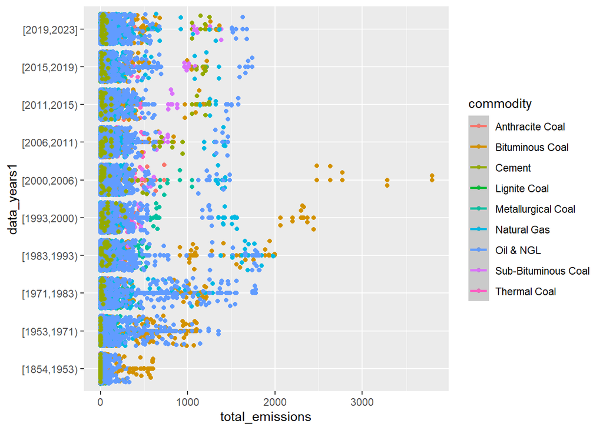

```r
ggplot(data, aes(x= data_years1, y = total_emissions, color = commodity)) +
    geom_point() +
    coord_flip() +
    geom_jitter() +
    geom_smooth(method = 'lm')
```

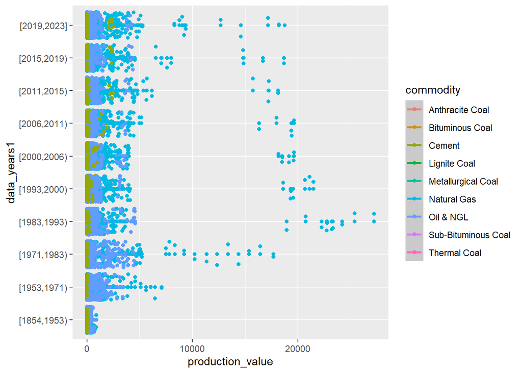

```r
ggplot(data, aes(x= data_years1, y = production_value, color = commodity)) +
    geom_point() +
    coord_flip() +
    geom_jitter() +
    geom_smooth(method = 'lm')
```

The emissions of Cement and Bituminous Coal seem unbound from production value which tells us something about how often they’re used and created, not dependent on market prices.

```r
#Explore those too
#IS Bituminous coal still in use
#Year-wise exploring
```

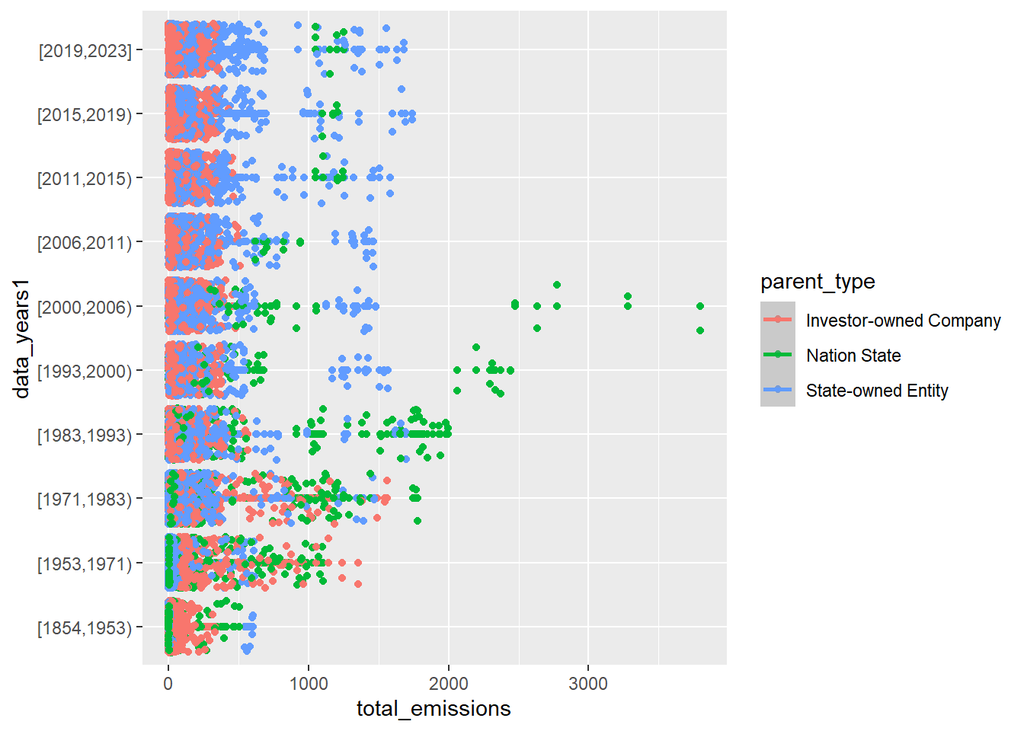

```r
ggplot(data, aes(x= data_years1, y = total_emissions, color = parent_type)) +
    geom_point() +
    coord_flip() +
    geom_jitter() +
    geom_smooth(method = 'lm')
```

```r
#ggplot(data, aes(x= data_years1, y = production_value, color = parent_type)) +
 #   geom_point() +
  #  coord_flip() +
   # geom_jitter() +
    # geom_smooth(method = 'lm')
```

## Means

To make graphing easier, I’m calculating the means of the emissions and production values

```r
mean_years =
  data %>%
  group_by(year) %>%
  summarize(mean_pv = mean(production_value),
            mean_te = mean(total_emissions))


mean_comm =
  data %>%
  group_by(commodity) %>%
  summarize(mean_pvc = mean(production_value),
            mean_tec = mean(total_emissions))


mean_type =
  data %>%
  group_by(parent_type) %>%
  summarize(mean_pvt = mean(production_value),
            mean_tet = mean(total_emissions))




mean_company =
  data %>%
  group_by(parent_entity) %>%
  summarize(company_mean_pv = mean(production_value),
            company_mean_te = mean(total_emissions))
```

```r
min_row_index <- which.min(mean_company$company_mean_te)

# Print the row
print(mean_company[min_row_index, ])
```

```
## # A tibble: 1 × 3
##   parent_entity       company_mean_pv company_mean_te
##   <chr>                         <dbl>           <dbl>
## 1 Westmoreland Mining            2.37            4.62
```

```r
max_row_index <- which.max(mean_company$company_mean_te)

# Print the index
#print(max_row_index)
print(mean_company[max_row_index, ])
```

```
## # A tibble: 1 × 3
##   parent_entity company_mean_pv company_mean_te
##   <chr>                   <dbl>           <dbl>
## 1 Gazprom                 9470.            740.
```

### Graphing Means

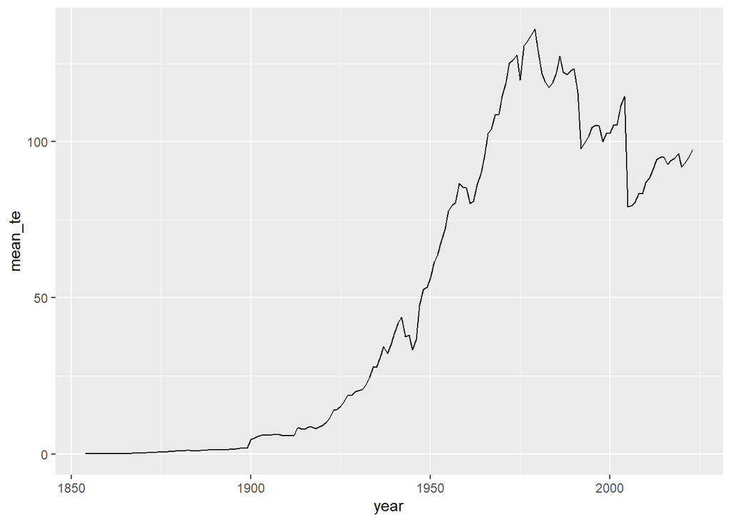

```r
ggplot(mean_years, aes (x = year, y = mean_te)) +
  geom_line()
```

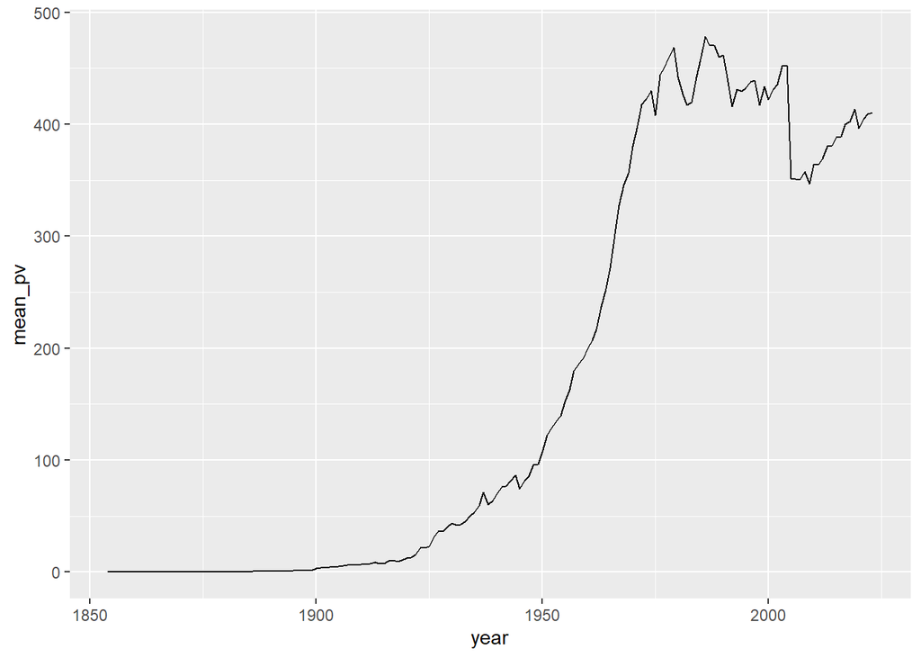

```r
ggplot(mean_years, aes (x = year, y = mean_pv)) +
  geom_line()
```

```r
#line stacked
```

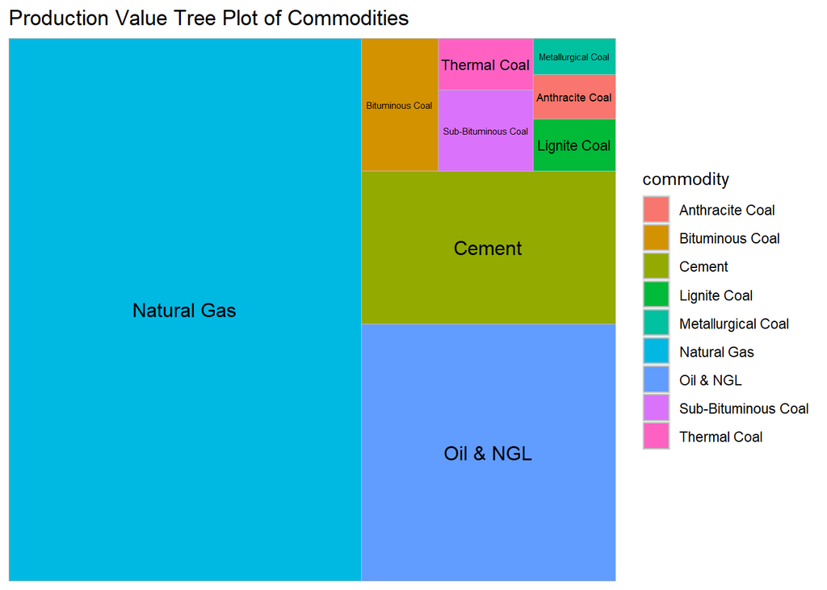

```r
ggplot2::ggplot(mean_comm,aes(area=mean_pvc,fill=commodity,label=commodity))+
  treemapify::geom_treemap(layout="squarified")+
  geom_treemap_text(place = "centre",size = 12)+
  labs(title="Production Value Tree Plot of Commodities")
```

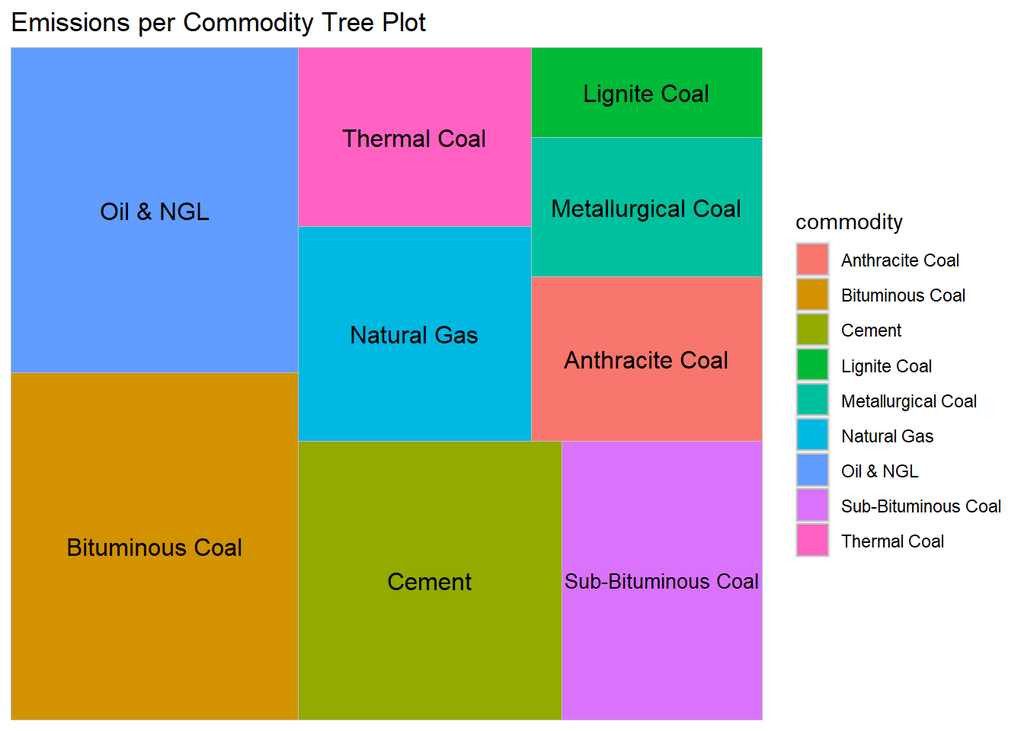

```r
ggplot2::ggplot(mean_comm,aes(area=mean_tec,fill=commodity,label=commodity))+
  treemapify::geom_treemap(layout="squarified")+
  geom_treemap_text(place = "centre",size = 12)+
  labs(title="Emissions per Commodity Tree Plot")
```

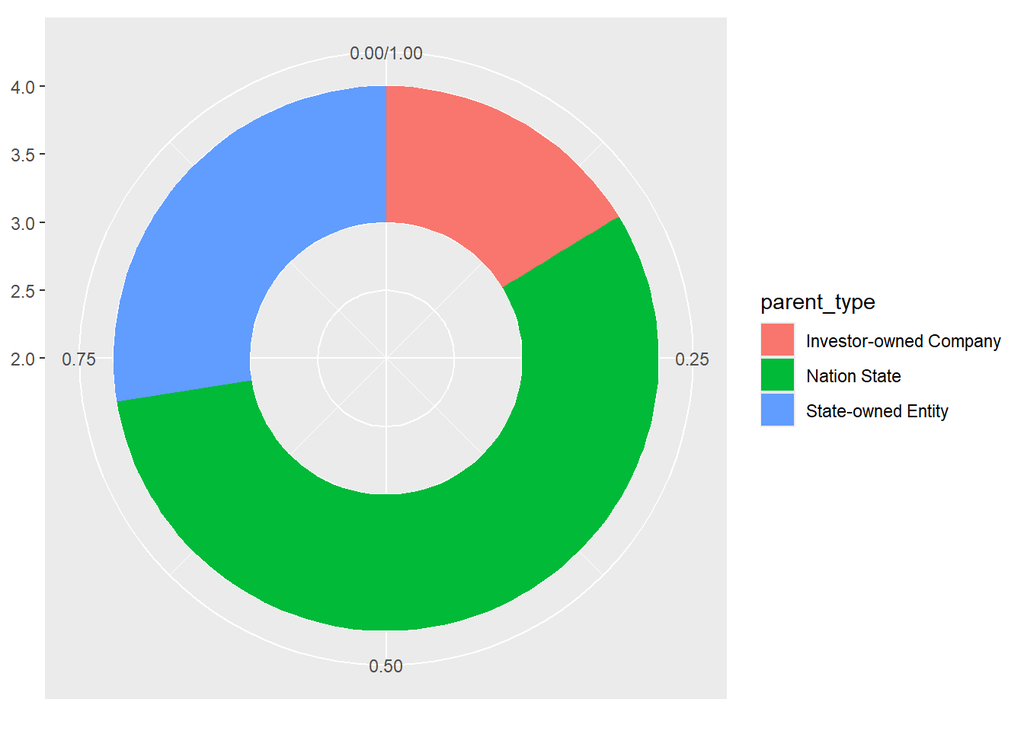

```r
#Doughnut Chart

# Compute percentages
mean_type$fraction = mean_type$mean_tet / sum(mean_type$mean_tet)

# Compute the cumulative percentages (top of each rectangle)
mean_type$ymax = cumsum(mean_type$fraction)

# Compute the bottom of each rectangle
mean_type$ymin = c(0, head(mean_type$ymax, n=-1))

ggplot(mean_type, aes(ymax=ymax, ymin=ymin, xmax=4, xmin=3, fill=parent_type)) +
     geom_rect() +
     coord_polar(theta="y") + # Try to remove that to understand how the chart is built initially
     xlim(c(2, 4)) # Try to remove that to see how to make a pie chart
```

## Data and the Hypotheses

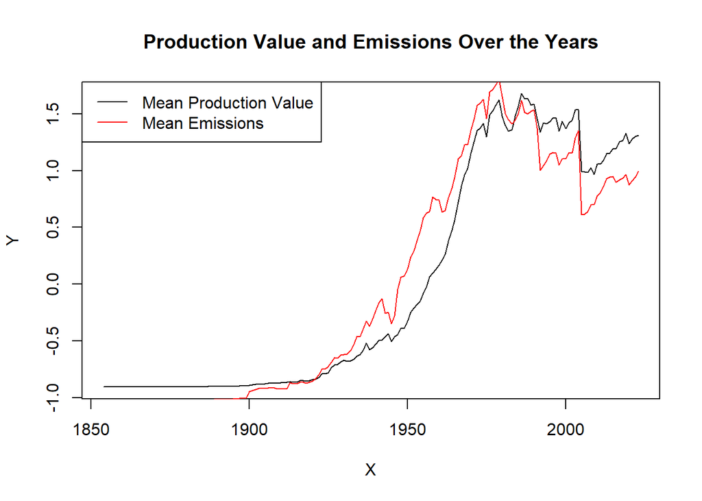

```r
# Create an empty plot
plot(mean_years$year, scale(mean_years$mean_pv), type = "n",
     xlab = "X", ylab = "Y", main = "Production Value and Emissions Over the Years")

# Plot each line one by one
lines(mean_years$year, scale(mean_years$mean_pv), type = "l", col = "black")
lines(mean_years$year, scale(mean_years$mean_te), type = "l", col = "red")


# Add a legend
legend("topleft", legend = c("Mean Production Value", "Mean Emissions"),
       col = c("black", "red"), lty = 1)
```